# super_bowl

### Q4: Which Musicians Performed the Most Songs?

```r
modern_halftime %>%
  arrange(desc(num_songs)) %>%
  head(5)
```

```
## # A tibble: 5 × 3
##   super_bowl musician          num_songs
##        <dbl> <chr>                 <dbl>
## 1         57 Rihanna                  14
## 2         52 Justin Timberlake        11
## 3         54 Shakira                  10
## 4         30 Diana Ross               10
## 5         58 Usher                     9
```

This shows the top 5 performers by num_songs in modern Super Bowls.

### Q5: Did the Number of Songs Increase Over Time?

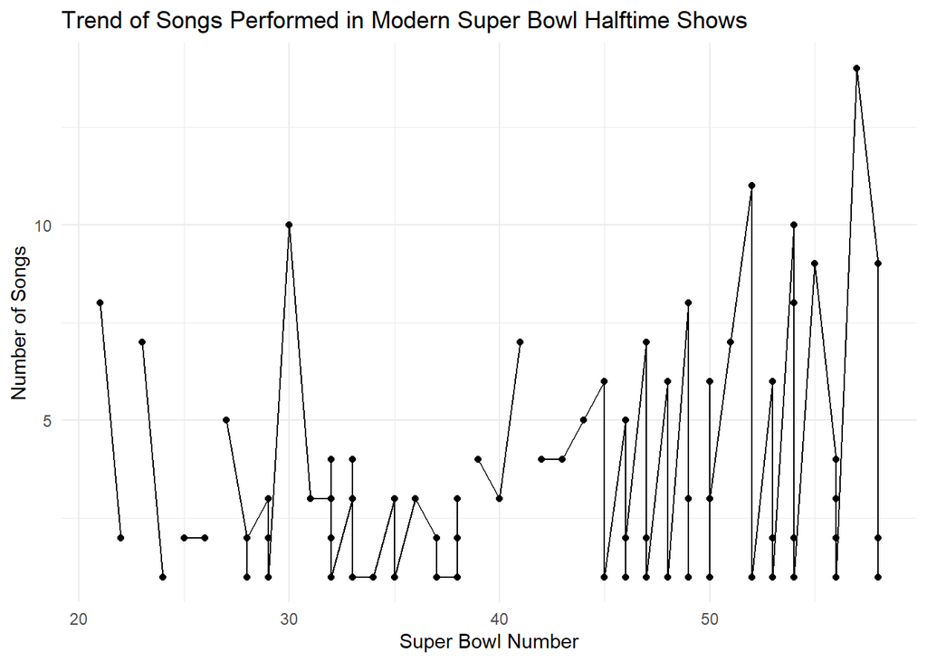

```r
ggplot(modern_halftime, aes(x = super_bowl, y = num_songs)) +
  geom_line() +
  geom_point() +
  labs(title = "Trend of Songs Performed in Modern Super Bowl Halftime Shows",
       x = "Super Bowl Number",
       y = "Number of Songs") +
  theme_minimal()
```

*interpretation*: This line chart shows the number of songs performed in modern Super Bowl halftime shows revealing considerable year-to-year fluctuation. In some years, only a few songs are performed, while others feature over ten. Although certain later Super Bowls reach higher peaks—likely reflecting increased production value and performer collaboration—there is no strict upward trend. Instead, creative and logistical factors (such as performer style, show format, and budget) play a significant role in shaping the performance. Overall, the data indicates that halftime shows can vary greatly in complexity, yet often become more elaborate in more recent Super Bowls.

### Q6: Compare Performances: Solo vs. Multiple Artists

**Aggregate Performance Data**

```r
performance_data <- modern_halftime %>%
  group_by(super_bowl) %>%
  summarize(
    num_musicians = n(),
    total_songs = sum(num_songs, na.rm = TRUE),
    primary_musician = first(musician)
  ) %>%
  ungroup() %>%
  mutate(
    performance_type = if_else(num_musicians > 1, "Multiple Artists", "Solo")
  )

print(performance_data)
```

```
## # A tibble: 38 × 5
##    super_bowl num_musicians total_songs primary_musician        performance_type
##         <dbl>         <int>       <dbl> <chr>                   <chr>
##  1         21             2          16 Grambling State Univer… Multiple Artists
##  2         22             3           2 Chubby Checker          Multiple Artists
##  3         23             1           7 Elvis Presto            Solo
##  4         24             6           3 Pete Fountain           Multiple Artists
##  5         25             1           2 New Kids on the Block   Solo
##  6         26             2           2 Gloria Estefan          Multiple Artists
##  7         27             1           5 Michael Jackson         Solo
##  8         28             5           9 Clint Black             Multiple Artists
##  9         29             4           8 Patti Labelle           Multiple Artists
## 10         30             1          10 Diana Ross              Solo
## # ℹ 28 more rows
```

**Merge with TV Data and Boxplot**

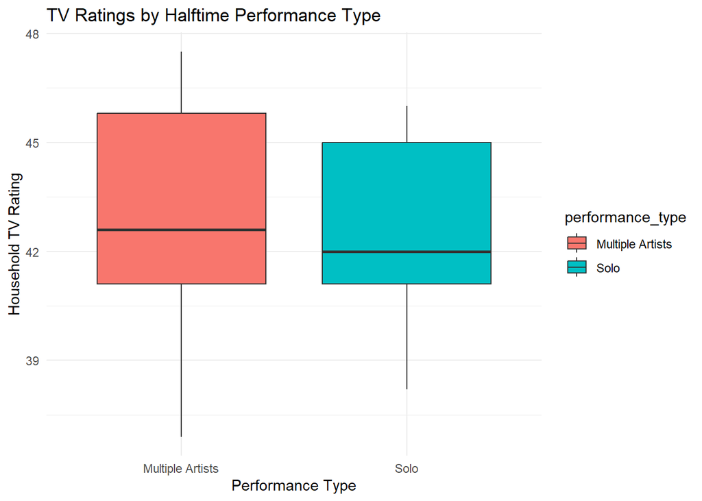

```r
halftime_tv <- performance_data %>%
  inner_join(modern_tv, by = "super_bowl")

ggplot(halftime_tv, aes(x = performance_type, y = rating_household, fill = performance_type)) +
  geom_boxplot() +
  labs(title = "TV Ratings by Halftime Performance Type",
       x = "Performance Type",
       y = "Household TV Rating") +
  theme_minimal()
```

*interpretation*: This boxplot compares household TV ratings for Super Bowls where the halftime show featured multiple artists versus a solo performer. Each box represents the distribution of ratings for that performance type:

Median Rating: The horizontal line within each box shows the median household rating.

Box & Whiskers: The box captures the middle 50% of the data, and the whiskers extend to cover a wider range of ratings. Visually, the two boxes are fairly close, suggesting that multiple-artist shows and solo performances both fall into a similar rating range. While multiple-artist performances may show slightly higher or more varied ratings, there isn’t a dramatic difference in medians. This indicates that, overall, having more performers doesn’t necessarily guarantee a significantly higher household rating—other factors (e.g., artist popularity, game competitiveness) likely play a larger role in driving viewership.

### Q7: Association Between Total Songs and TV Ratings

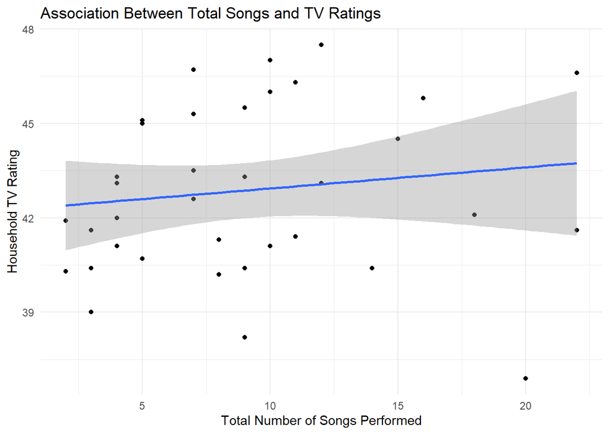

```r
ggplot(halftime_tv, aes(x = total_songs, y = rating_household)) +
  geom_point() +
  geom_smooth(method = "lm") +
  labs(title = "Association Between Total Songs and TV Ratings",
       x = "Total Number of Songs Performed",
       y = "Household TV Rating") +
  theme_minimal()
```

```r
correlation <- cor(halftime_tv$total_songs, halftime_tv$rating_household, use = "complete.obs")
paste("Correlation between total songs and TV rating:", round(correlation, 3))
```

```
## [1] "Correlation between total songs and TV rating: 0.138"
```

*interpretation*: visually, the trend line has a slight positive slope, indicating that, in general, higher numbers of total songs performed are marginally associated with higher household TV ratings. However, the points are somewhat scattered, suggesting that total songs alone do not strongly predict household ratings.

**Correlation (r = 0.138)**

- The correlation coefficient of 0.138 indicates a weak positive relationship between the total number of songs performed and household TV ratings.
- A correlation of 0.138 is close to zero, which implies that while there is a slight tendency for more songs to coincide with slightly higher ratings, the relationship is not very strong.

### Q8: Identify the Highest Rated Halftime Show

```r
highest_rated <- halftime_tv %>%
  arrange(desc(rating_household)) %>%
  select(super_bowl, performance_type, primary_musician, rating_household, total_songs) %>%
  head(1)

highest_rated
```

```
## # A tibble: 1 × 5
##   super_bowl performance_type primary_musician rating_household total_songs
##        <dbl> <chr>            <chr>                       <dbl>       <dbl>
## 1         49 Multiple Artists Katy Perry                   47.5          12
```